# 2020.05

# table 1 grouped by radscores

```r
library(kableExtra)
label = rep("Primary Cohort",177)
label[-rowTrain] = "Validation Cohort"
data.tbl = data.tbl %>%
  mutate(cohort = label)

primary = data.tbl[rowTrain,]
validation = data.tbl[-rowTrain,]


control = arsenal::tableby.control(test = T,
                                    numeric.stats = c("meansd","medianq1q3","range"),
                                    #cat.stats = c("countrowpct"),
                                    ordered.stats = c("Nmiss"),
                                    digits = 2)

tbl_primary = arsenal::tableby(PCR~ Age + Sex + Group + cT + cN +cTNM + MRF + `Tumor length` + `Tumor thickness` + Distance + CEA  + Differentiation + radscore, data = primary,control = control)

tbl_validation = arsenal::tableby(PCR~ Age + Sex + Group + cT + cN +cTNM + MRF + `Tumor length` + `Tumor thickness` + Distance + CEA  + Differentiation + radscore, data = validation, control = control)

summary(tbl_primary,text = T) %>%
  knitr::kable(booktabs = T, caption = "Descriptive Statistics") %>%
  kable_styling(latex_options = c("striped", "hold_position"))
```

Descriptive Statistics

N (N=103)

Y (N=22)

Total (N=125)

p value

Age

0.195

- 0

71 (68.9%)

12 (54.5%)

83 (66.4%)

- 1

32 (31.1%)

10 (45.5%)

42 (33.6%)

Sex

0.862

- Female

30 (29.1%)

6 (27.3%)

36 (28.8%)

- Male

73 (70.9%)

16 (72.7%)

89 (71.2%)

Group

0.006

- A

31 (30.1%)

5 (22.7%)

36 (28.8%)

- B

19 (18.4%)

11 (50.0%)

30 (24.0%)

- C

53 (51.5%)

6 (27.3%)

59 (47.2%)

cT

0.236

- 3

89 (86.4%)

21 (95.5%)

110 (88.0%)

- 4

14 (13.6%)

1 (4.5%)

15 (12.0%)

cN

0.317

- 0

24 (23.3%)

3 (13.6%)

27 (21.6%)

- 1

79 (76.7%)

19 (86.4%)

98 (78.4%)

cTNM

0.481

- 2

26 (25.2%)

4 (18.2%)

30 (24.0%)

- 3

77 (74.8%)

18 (81.8%)

95 (76.0%)

MRF

0.792

- 0

72 (69.9%)

16 (72.7%)

88 (70.4%)

- 1

31 (30.1%)

6 (27.3%)

37 (29.6%)

Tumor length

0.291

- 0

22 (21.4%)

7 (31.8%)

29 (23.2%)

- 1

81 (78.6%)

15 (68.2%)

96 (76.8%)

Tumor thickness

0.333

- Mean (SD)

15.80 (6.70)

17.45 (9.55)

16.09 (7.26)

- Median (Q1, Q3)

15.00 (11.50, 18.00)

13.50 (12.00, 20.50)

15.00 (12.00, 18.00)

- Range

7.50 - 51.00

9.00 - 47.00

7.50 - 51.00

Distance

0.292

- 0

39 (37.9%)

11 (50.0%)

50 (40.0%)

- 1

64 (62.1%)

11 (50.0%)

75 (60.0%)

CEA

0.601

- 0

69 (67.0%)

16 (72.7%)

85 (68.0%)

- 1

34 (33.0%)

6 (27.3%)

40 (32.0%)

Differentiation

0.476

- 0

46 (44.7%)

8 (36.4%)

54 (43.2%)

- 1

57 (55.3%)

14 (63.6%)

71 (56.8%)

radscore

< 0.001

- Mean (SD)

-4.79 (3.87)

1.40 (1.46)

-3.70 (4.28)

- Median (Q1, Q3)

-3.80 (-6.20, -2.44)

1.26 (0.71, 2.22)

-3.36 (-5.36, -1.49)

- Range

-27.86 - 0.50

-1.94 - 4.04

-27.86 - 4.04

```r
summary(tbl_validation,text = T) %>%
  knitr::kable(booktabs = T, caption = "Descriptive Statistics") %>%
  kable_styling(latex_options = c("striped", "hold_position"))
```

Descriptive Statistics

N (N=43)

Y (N=9)

Total (N=52)

p value

Age

0.160

- 0

28 (65.1%)

8 (88.9%)

36 (69.2%)

- 1

15 (34.9%)

1 (11.1%)

16 (30.8%)

Sex

0.785

- Female

17 (39.5%)

4 (44.4%)

21 (40.4%)

- Male

26 (60.5%)

5 (55.6%)

31 (59.6%)

Group

0.042

- A

13 (30.2%)

1 (11.1%)

14 (26.9%)

- B

14 (32.6%)

7 (77.8%)

21 (40.4%)

- C

16 (37.2%)

1 (11.1%)

17 (32.7%)

cT

0.052

- 3

33 (76.7%)

4 (44.4%)

37 (71.2%)

- 4

10 (23.3%)

5 (55.6%)

15 (28.8%)

cN

0.417

- 0

10 (23.3%)

1 (11.1%)

11 (21.2%)

- 1

33 (76.7%)

8 (88.9%)

41 (78.8%)

cTNM

0.417

- 2

10 (23.3%)

1 (11.1%)

11 (21.2%)

- 3

33 (76.7%)

8 (88.9%)

41 (78.8%)

MRF

0.193

- 0

33 (76.7%)

5 (55.6%)

38 (73.1%)

- 1

10 (23.3%)

4 (44.4%)

14 (26.9%)

Tumor length

0.744

- 0

12 (27.9%)

3 (33.3%)

15 (28.8%)

- 1

31 (72.1%)

6 (66.7%)

37 (71.2%)

Tumor thickness

0.234

- Mean (SD)

15.45 (4.71)

17.44 (3.36)

15.80 (4.54)

- Median (Q1, Q3)

15.00 (12.50, 18.00)

16.00 (15.00, 21.00)

15.00 (13.00, 18.00)

- Range

8.00 - 32.00

13.00 - 22.00

8.00 - 32.00

Distance

0.685

- 0

16 (37.2%)

4 (44.4%)

20 (38.5%)

- 1

27 (62.8%)

5 (55.6%)

32 (61.5%)

CEA

0.246

- 0

28 (65.1%)

4 (44.4%)

32 (61.5%)

- 1

15 (34.9%)

5 (55.6%)

20 (38.5%)

Differentiation

0.635

- 0

18 (41.9%)

3 (33.3%)

21 (40.4%)

- 1

25 (58.1%)

6 (66.7%)

31 (59.6%)

radscore

< 0.001

- Mean (SD)

-4.15 (2.65)

-0.02 (1.17)

-3.43 (2.91)

- Median (Q1, Q3)

-3.78 (-5.08, -2.10)

-0.26 (-0.47, 0.58)

-3.25 (-4.92, -1.45)

- Range

-11.36 - -0.00

-1.54 - 2.43

-11.36 - 2.43

# Making ROC curves for logistic regression Models

## for training set

```r
# rad.fit ROC (radscore and others)
rad.fit.pred.train.prob = predict(rad.fit,newdata = data.pred[rowTrain,],type = "prob")[,2]# select pos resp
rad.fit.pred.train = rep("N",length(rad.fit.pred.train.prob))
rad.fit.pred.train[rad.fit.pred.train.prob > 0.5] = "Y"

roc.rad.fit = roc(data.pred$PCR[rowTrain], rad.fit.pred.train.prob)
```

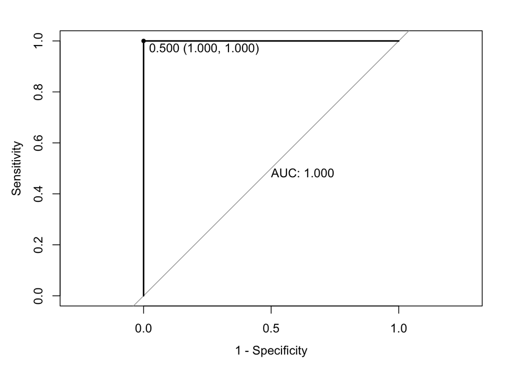

```r
plot(roc.rad.fit,
     legacy.axes = T,
     print.auc = T,
     print.thres = T)
```

```r
ci.auc(roc.rad.fit)
```

```
## 95% CI: 1-1 (DeLong)
```

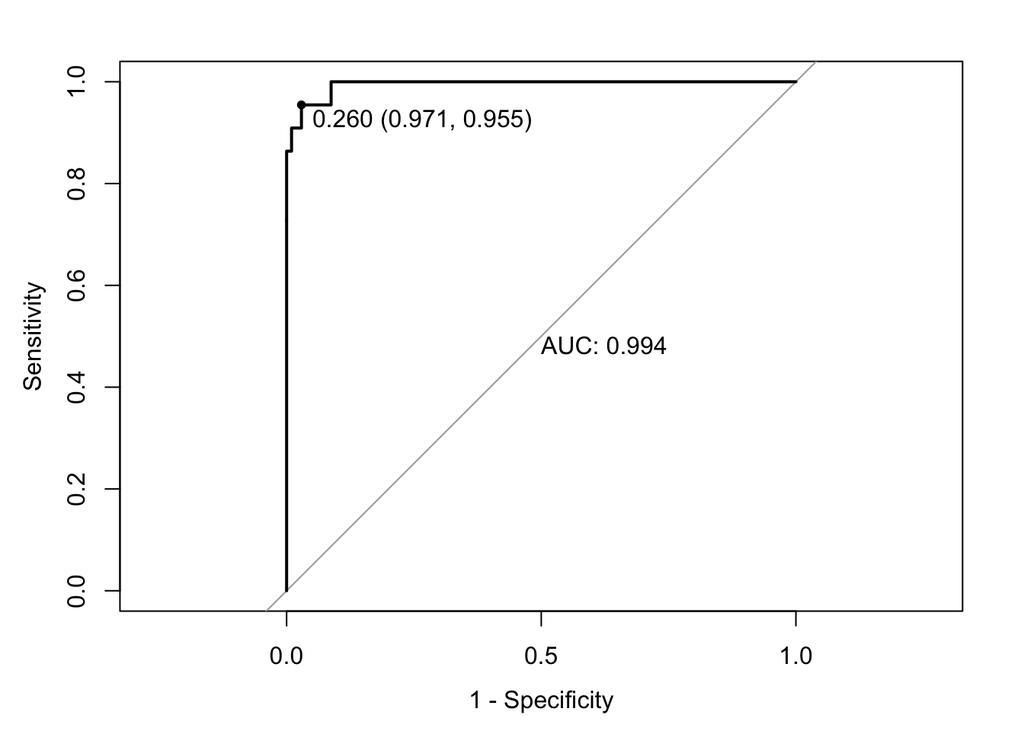

```r
#plot(smooth(rad_and_group.fit.fit),
     #add = T,
     #col = 4)
# only radscore and groups
rad_group.fit.pred.train.prob = predict(rad_and_group.fit ,newdata = data.pred[rowTrain,],type = "prob")[,2]# select pos resp
rad_group.fit.pred.train = rep("N",length(rad_group.fit.pred.train.prob))
rad_group.fit.pred.train[rad_group.fit.pred.train.prob > 0.5] = "Y"

roc.rad_group.fit = roc(data.pred$PCR[rowTrain], rad_group.fit.pred.train.prob)
plot(roc.rad_group.fit,
     legacy.axes = T,
     print.auc = T,
     print.thres = T)
```

```r
ci.auc(roc.rad_group.fit)
```

```
## 95% CI: 0.9852-1 (DeLong)
```

```r
# RF train ROC
rf.fit.pred.train.prob = predict(rf.fit,newdata = data.pred[rowTrain,-1],type = "prob")[,2]# select pos resp
rf.fit.pred.train = rep("N",length(rf.fit.pred.train.prob))
rf.fit.pred.train[rf.fit.pred.train.prob > 0.5] = "Y"

roc.rf.fit = roc(data.pred$PCR[rowTrain], rf.fit.pred.train.prob)
```

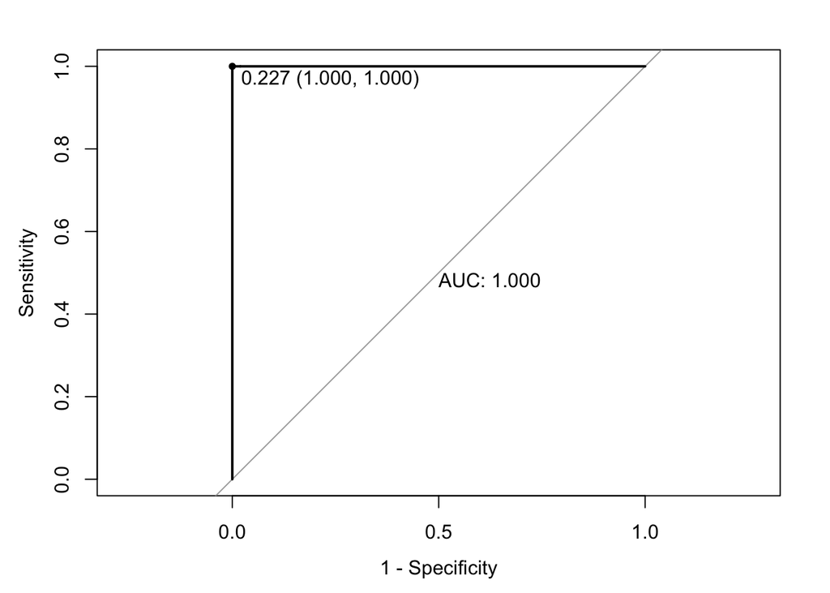

```r
plot(roc.rf.fit,
     legacy.axes = T,
     print.auc = T,
     print.thres = T)
```

```r
ci.auc(roc.rf.fit)
```

```
## 95% CI: 1-1 (DeLong)
```

```r
# Boosting train ROC
gbmB.fit.pred.train.prob = predict(gbmB.fit, newdata = data.pred[rowTrain,-1], type = "prob")[,2]# select pos resp
gbmB.fit.pred.train = rep("N",length(gbmB.fit.pred.train.prob))
gbmB.fit.pred.train[gbmB.fit.pred.train.prob > 0.5] = "Y"

roc.gbmB.fit = roc(data.pred$PCR[rowTrain], gbmB.fit.pred.train.prob)
```

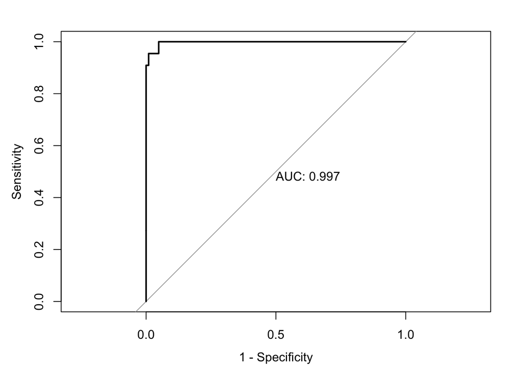

```r
plot(roc.gbmB.fit,
     legacy.axes = T,
     print.auc = T)
```

```r
ci.auc(roc.gbmB.fit)
```

```
## 95% CI: 0.9924-1 (DeLong)
```

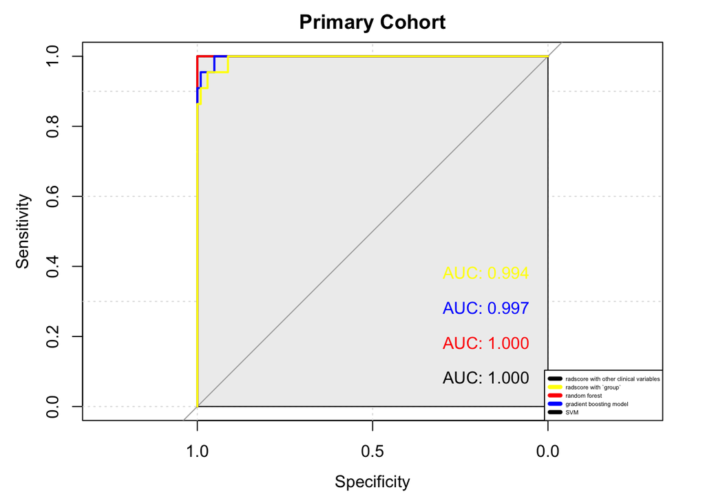

```r
plot(roc.rad.fit, print.auc=TRUE,print.auc.x=0.3,print.auc.y=0.1,auc.polygon.col="gray", grid = c(0.5, 0.3), max.auc.polygon=TRUE,legen = T,main = "Primary Cohort")
plot.roc(roc.rf.fit,add=T,col="red", print.auc=TRUE,print.auc.x=0.3,print.auc.y=0.2)
plot.roc(roc.gbmB.fit,add=T,col="blue",print.auc=TRUE,print.auc.x=0.3,print.auc.y=0.3,)
plot.roc(roc.rad_group.fit,add=T,col="yellow",print.auc=TRUE,print.auc.x=0.3,print.auc.y=0.4)
legend("bottomright",legend = c("radscore with other clinical variables",
                  "radscore with `group`",
                  "random forest",
                  "gradient boosting model",
                  "SVM"),
       col = c("black","yellow","red","blue"),lwd = 4,cex = 0.35)
```

[output not shown]

## for validation set

```r
# rad.fit ROC (radscore and others)
rad.fit.pred.test.prob = predict(rad.fit,newdata = data.pred[-rowTrain,],type = "prob")[,2]# select pos resp
rad.fit.pred.test = rep("N",length(rad.fit.pred.test.prob))
rad.fit.pred.test[rad.fit.pred.test.prob > 0.5] = "Y"

roc.rad.fit.test = roc(data.pred$PCR[-rowTrain], rad.fit.pred.test.prob)
```

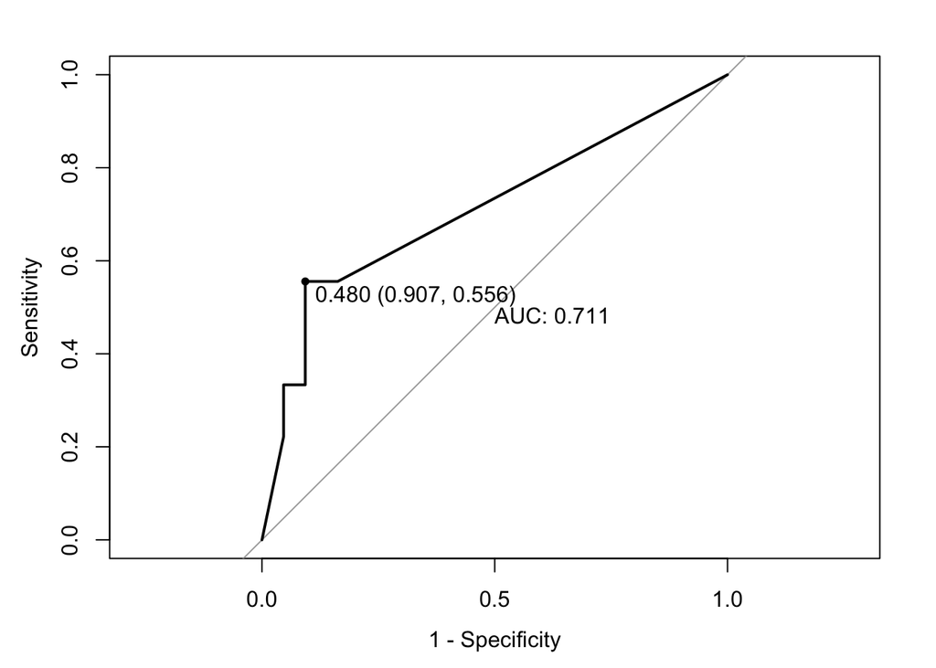

```r
plot(roc.rad.fit.test,
     legacy.axes = T,
     print.auc = T,
     print.thres = T)
```

```r
ci.auc(roc.rad.fit.test)
```

```
## 95% CI: 0.5218-0.8994 (DeLong)
```

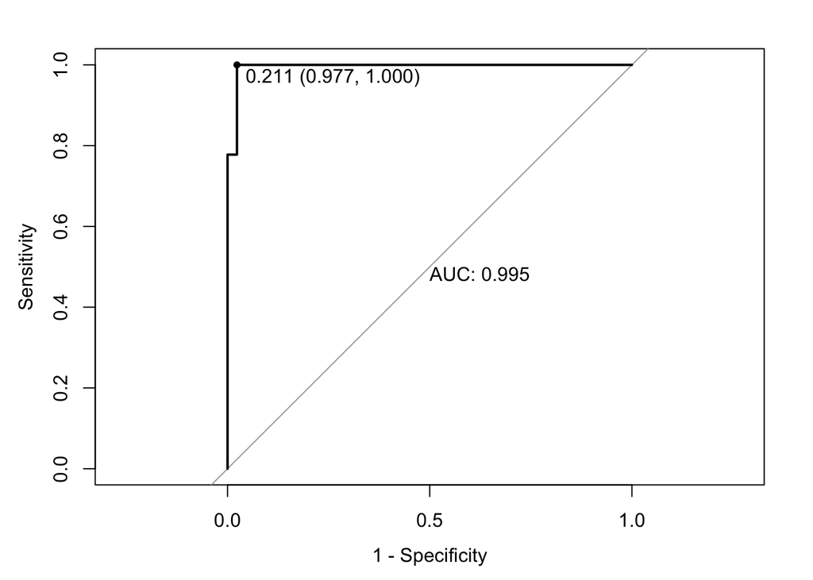

```r
#plot(smooth(rad_and_group.fit.fit),
     #add = T,
     #col = 4)

# only radscore and groups
rad_group.fit.pred.test.prob = predict(rad_and_group.fit ,newdata = data.pred[-rowTrain,],type = "prob")[,2]# select pos resp
rad_group.fit.pred.test = rep("N",length(rad_group.fit.pred.test.prob))
rad_group.fit.pred.test[rad_group.fit.pred.test.prob > 0.5] = "Y"

roc.rad_group.fit.test = roc(data.pred$PCR[-rowTrain], rad_group.fit.pred.test.prob)
plot(roc.rad_group.fit.test,
     legacy.axes = T,
     print.auc = T,
     print.thres = T)
```

```r
ci.auc(roc.rad_group.fit.test)
```

```
## 95% CI: 0.9827-1 (DeLong)
```

```r
# RF train ROC
rf.fit.pred.test.prob = predict(rf.fit,newdata = data.pred[-rowTrain,-1],type = "prob")[,2]# select pos resp
rf.fit.pred.test = rep("N",length(rf.fit.pred.test.prob))
rf.fit.pred.test[rf.fit.pred.test.prob > 0.5] = "Y"

roc.rf.fit.test = roc(data.pred$PCR[-rowTrain], rf.fit.pred.test.prob)
```

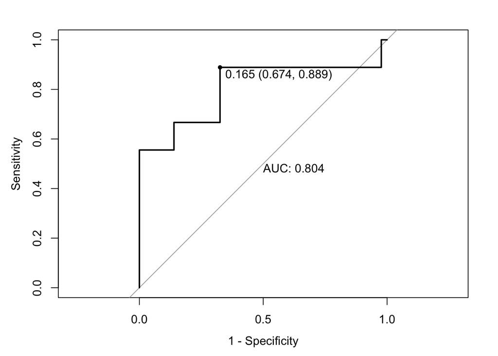

```r
plot(roc.rf.fit.test,
     legacy.axes = T,
     print.auc = T,
     print.thres = T)
```

```r
ci.auc(roc.rf.fit.test)
```

```
## 95% CI: 0.5883-1 (DeLong)
```

```r
# Boosting test ROC
gbmB.fit.pred.test.prob = predict(gbmB.fit,newdata = data.pred[-rowTrain,-1], type = "prob")[,2]# select pos resp
gbmB.fit.pred.test = rep("N",length(gbmB.fit.pred.test.prob))
gbmB.fit.pred.test[gbmB.fit.pred.test.prob > 0.5] = "Y"

roc.gbmB.fit.test = roc(data.pred$PCR[-rowTrain], gbmB.fit.pred.test.prob)
```

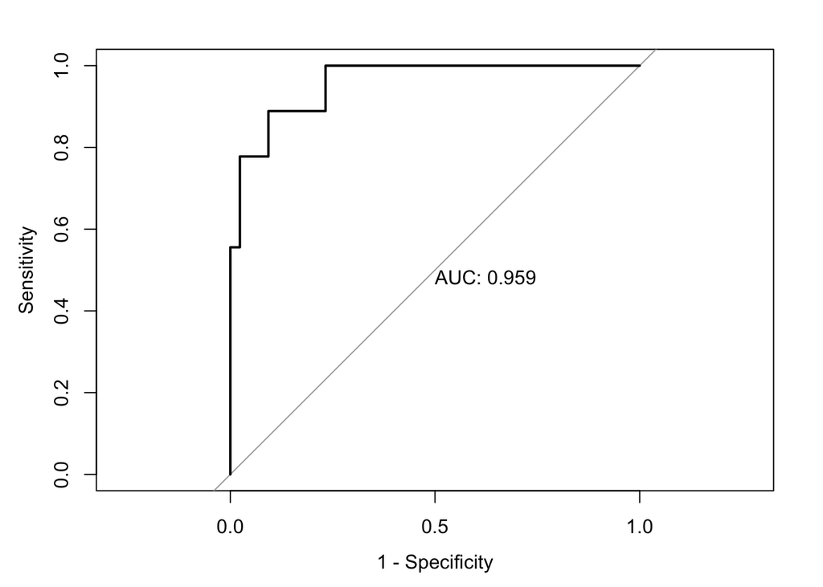

```r
plot(roc.gbmB.fit.test,
     legacy.axes = T,
     print.auc = T)
```

```r
ci.auc(roc.gbmB.fit.test)
```

```
## 95% CI: 0.901-1 (DeLong)
```

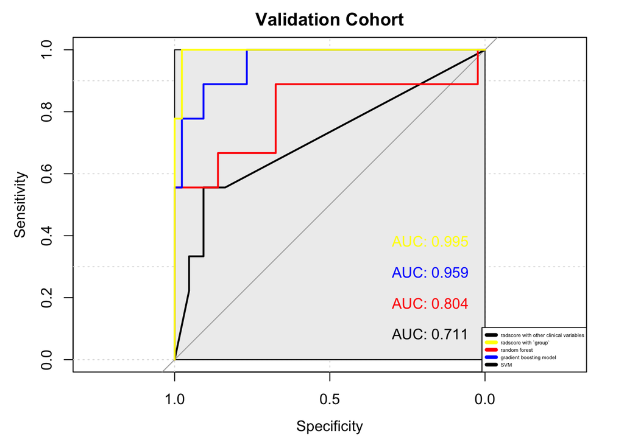

```r
plot(roc.rad.fit.test, print.auc=TRUE,print.auc.x = 0.3,print.auc.y= 0.1,grid = c(0.5, 0.3), max.auc.polygon=TRUE,legen = T,main = "Validation Cohort")
plot.roc(roc.rf.fit.test,add=T,col="red", print.auc=TRUE,print.auc.x=0.3,print.auc.y=0.2)
plot.roc(roc.gbmB.fit.test,add=T,col="blue",print.auc=TRUE,print.auc.x=0.3,print.auc.y=0.3,)
plot.roc(roc.rad_group.fit.test,add=T,col="yellow",print.auc=TRUE,print.auc.x=0.3,print.auc.y=0.4)
legend("bottomright",legend = c("radscore with other clinical variables",
                  "radscore with `group`",
                  "random forest",
                  "gradient boosting model",
                  "SVM"),
       col = c("black","yellow","red","blue"),lwd = 4,cex = 0.35)
```

[output not shown]